# JIP45_HW4_INFSCI2160

Jing Pang

2/22/2019

```r
library(dplyr)
```

```r
library(ggplot2)
library(pROC)
library(tree)
library(glmnet)
library(rsample)
library(MASS)
library(e1071)
library(randomForest)
library(class)
library(caret)
library(gridExtra)
# import dataset
telcustomer<- read.csv("~/Dropbox/19 Spring/INFSCI_2160_DM/HWs/HW4/WA_Fn-UseC_-Telco-Customer-Churn.csv")

# summary of dataset
summary(telcustomer)
```

```
##       customerID      gender     SeniorCitizen    Partner    Dependents
##  0002-ORFBO:   1   Female:3488   Min.   :0.0000   No :3641   No :4933
##  0003-MKNFE:   1   Male  :3555   1st Qu.:0.0000   Yes:3402   Yes:2110
##  0004-TLHLJ:   1                 Median :0.0000
##  0011-IGKFF:   1                 Mean   :0.1621
##  0013-EXCHZ:   1                 3rd Qu.:0.0000
##  0013-MHZWF:   1                 Max.   :1.0000
##  (Other)   :7037
##      tenure      PhoneService          MultipleLines     InternetService
##  Min.   : 0.00   No : 682     No              :3390   DSL        :2421
##  1st Qu.: 9.00   Yes:6361     No phone service: 682   Fiber optic:3096
##  Median :29.00                Yes             :2971   No         :1526
##  Mean   :32.37
##  3rd Qu.:55.00
##  Max.   :72.00
##
##              OnlineSecurity              OnlineBackup
##  No                 :3498   No                 :3088
##  No internet service:1526   No internet service:1526
##  Yes                :2019   Yes                :2429
##
##
##
##
##             DeviceProtection              TechSupport
##  No                 :3095    No                 :3473
##  No internet service:1526    No internet service:1526
##  Yes                :2422    Yes                :2044
##
##
##
##
##               StreamingTV              StreamingMovies
##  No                 :2810   No                 :2785
##  No internet service:1526   No internet service:1526
##  Yes                :2707   Yes                :2732
##
##
##
##
##            Contract    PaperlessBilling                   PaymentMethod
##  Month-to-month:3875   No :2872         Bank transfer (automatic):1544
##  One year      :1473   Yes:4171         Credit card (automatic)  :1522
##  Two year      :1695                    Electronic check         :2365
##                                         Mailed check             :1612
##
##
##
##  MonthlyCharges    TotalCharges    Churn
##  Min.   : 18.25   Min.   :  18.8   No :5174
##  1st Qu.: 35.50   1st Qu.: 401.4   Yes:1869
##  Median : 70.35   Median :1397.5
##  Mean   : 64.76   Mean   :2283.3
##  3rd Qu.: 89.85   3rd Qu.:3794.7
##  Max.   :118.75   Max.   :8684.8
##                   NA's   :11
```

```r
# clearly there is some null values, but it is not too much, therefore, we just simply remove it from dataset
sum(is.na(telcustomer))
```

```
## [1] 11
```

```r
telcustomer_cl <- na.omit(telcustomer)

# normalization
telcustomer_cl$MonthlyCharges <- scale(telcustomer_cl$MonthlyCharges)
telcustomer_cl$TotalCharges <- scale(telcustomer_cl$TotalCharges)

# transfter target variable into numeric for later examination
telcustomer_cl$Churn_num <- ifelse(telcustomer_cl$Churn=="Yes",1,0)

summary(telcustomer_cl)
```

```
##       customerID      gender     SeniorCitizen    Partner    Dependents
##  0002-ORFBO:   1   Female:3483   Min.   :0.0000   No :3639   No :4933
##  0003-MKNFE:   1   Male  :3549   1st Qu.:0.0000   Yes:3393   Yes:2099
##  0004-TLHLJ:   1                 Median :0.0000
##  0011-IGKFF:   1                 Mean   :0.1624
##  0013-EXCHZ:   1                 3rd Qu.:0.0000
##  0013-MHZWF:   1                 Max.   :1.0000
##  (Other)   :7026
##      tenure      PhoneService          MultipleLines     InternetService
##  Min.   : 1.00   No : 680     No              :3385   DSL        :2416
##  1st Qu.: 9.00   Yes:6352     No phone service: 680   Fiber optic:3096
##  Median :29.00                Yes             :2967   No         :1520
##  Mean   :32.42
##  3rd Qu.:55.00
##  Max.   :72.00
##
##              OnlineSecurity              OnlineBackup
##  No                 :3497   No                 :3087
##  No internet service:1520   No internet service:1520
##  Yes                :2015   Yes                :2425
##
##
##
##
##             DeviceProtection              TechSupport
##  No                 :3094    No                 :3472
##  No internet service:1520    No internet service:1520
##  Yes                :2418    Yes                :2040
##
##
##
##
##               StreamingTV              StreamingMovies
##  No                 :2809   No                 :2781
##  No internet service:1520   No internet service:1520
##  Yes                :2703   Yes                :2731
##
##
##
##
##            Contract    PaperlessBilling                   PaymentMethod
##  Month-to-month:3875   No :2864         Bank transfer (automatic):1542
##  One year      :1472   Yes:4168         Credit card (automatic)  :1521
##  Two year      :1685                    Electronic check         :2365
##                                         Mailed check             :1604
##
##
##
##   MonthlyCharges.V1     TotalCharges.V1    Churn        Churn_num
##  Min.   :-1.5471731   Min.   :-0.9989982   No :5163   Min.   :0.0000
##  1st Qu.:-0.9709078   1st Qu.:-0.8301898   Yes:1869   1st Qu.:0.0000
##  Median : 0.1845309   Median :-0.3907873              Median :0.0000
##  Mean   : 0.0000000   Mean   : 0.0000000              Mean   :0.2658
##  3rd Qu.: 0.8330889   3rd Qu.: 0.6667797              3rd Qu.:1.0000
##  Max.   : 1.7932540   Max.   : 2.8240605              Max.   :1.0000
##
```

```r
# prepare dataset
# split dataset into train and test partitions
telcustomer_train_test_split <- initial_split(telcustomer_cl,0.8)
telcustomer_train_tbl <- training(telcustomer_train_test_split)
telcustomer_test_tbl <- testing(telcustomer_train_test_split)
```

### Question #1:

Run k-fold cross validation with a random forest model on your training data. List your most important predictors in order from most important to least. How many predictors are optimal for this dataset?

```r
# run random forest model on training data
set.seed(1234)
telcustomer_train_rf_whole <- randomForest(formula = Churn ~ gender+SeniorCitizen+Partner+Dependents+tenure+PhoneService+…, data = telcustomer_train_tbl, importance = TRUE, ntree = 50)
telcustomer_var_importance <- data.frame(importance(telcustomer_train_rf_whole))
telcustomer_var_importance
```

```
##                          No        Yes MeanDecreaseAccuracy
## gender            0.4912253  0.4791525            0.6604996
## SeniorCitizen     4.6571427 -1.4990282            2.9368435
## Partner           3.0013497  2.5507300            3.9871569
## Dependents       -0.2915514  2.1309293            1.4237456
## tenure            9.9844679  6.6644483           14.3500612
## PhoneService      0.1158365  1.2175412            0.8906723
## MultipleLines     1.2617934  2.6490863            2.9188295
## InternetService   5.7033420  6.9910191            8.5568000
## OnlineSecurity    5.1924296  7.1429997            7.3556602
## OnlineBackup      3.4237978  2.9009011            4.8424814
## DeviceProtection  4.9608365 -3.6436101            4.0698789
## TechSupport       3.8088818  9.7322826            6.5578364
## StreamingTV       4.5912704  1.4804872            4.6614288
## StreamingMovies   3.2060646  0.1585746            3.3902298
## Contract          2.5844884  9.6829655            9.7244259
## PaperlessBilling -2.0767086  5.1149635            1.9549445
## PaymentMethod     1.2930893  5.1093077            4.1744906
## MonthlyCharges    8.3134676  4.8938514           10.1839216
## TotalCharges      9.9075630  4.5115160           15.3179403
##                  MeanDecreaseGini
## gender                  50.381870
## SeniorCitizen           41.888522
## Partner                 40.859377
## Dependents              37.228575
## tenure                 334.834711
## PhoneService             9.951485
## MultipleLines           44.407166
## InternetService         78.496595
## OnlineSecurity         103.797723
## OnlineBackup            49.772163
## DeviceProtection        44.082340
## TechSupport             87.369997
## StreamingTV             38.008728
## StreamingMovies         38.337083
## Contract               103.614714
## PaperlessBilling        45.242716
## PaymentMethod          120.848734
## MonthlyCharges         309.129151
## TotalCharges           347.368040
```

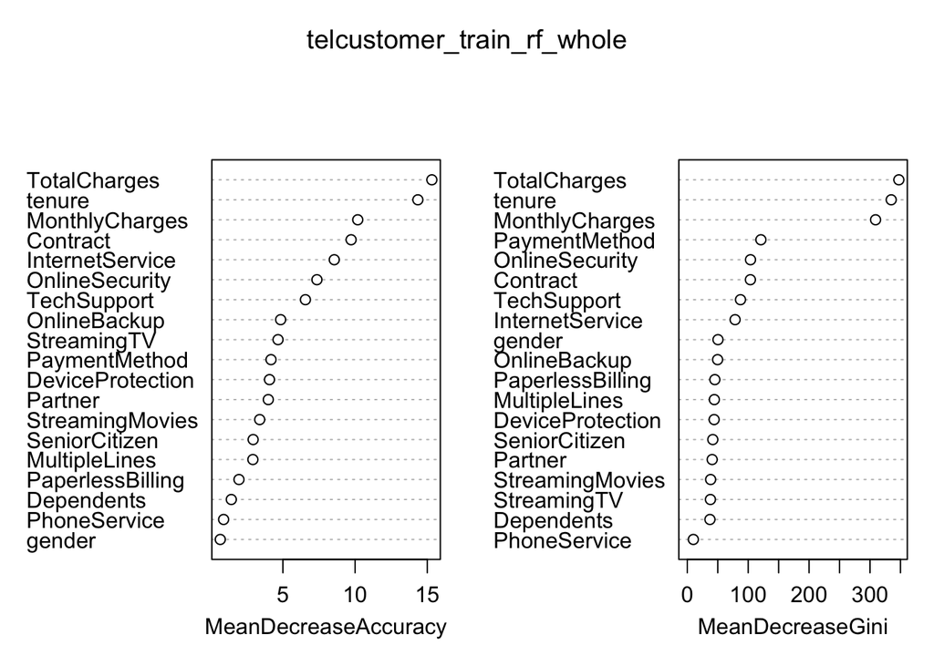

```r
varImpPlot(telcustomer_train_rf_whole)
```

```r
# cross-validation
telcustomer_cvrf <- rfcv(telcustomer_train_tbl[,c(2:20)], telcustomer_train_tbl$Churn_num, cv.fold = 5, step = .5)
```

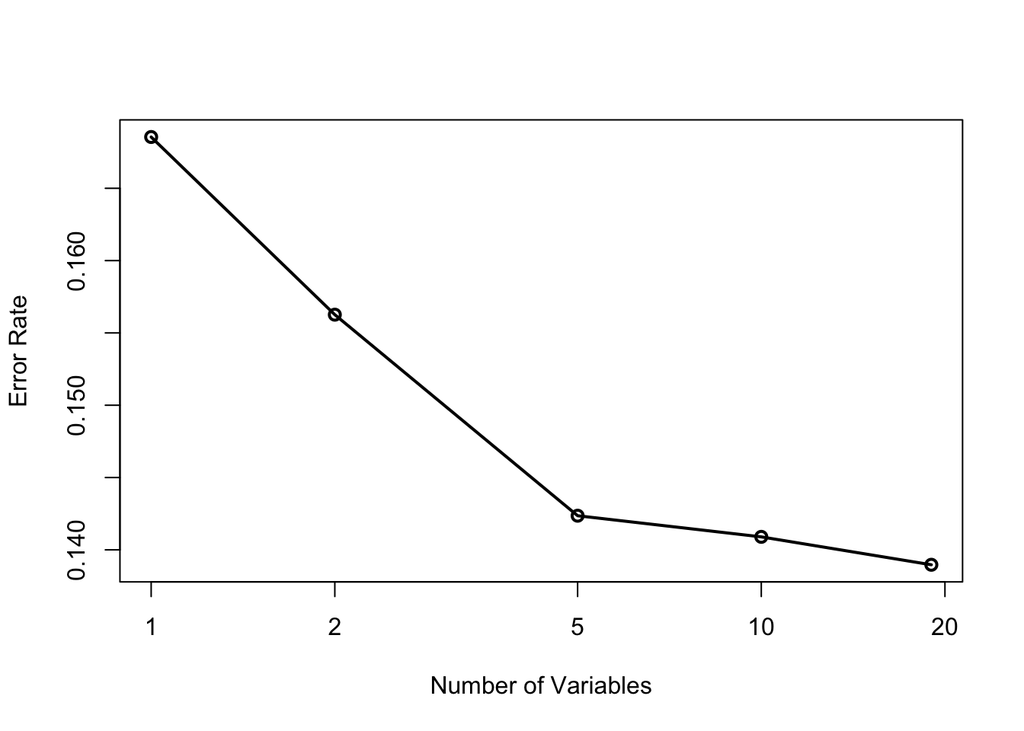

```r
with(telcustomer_cvrf, plot(n.var, error.cv, log="x", type="o", lwd=2,
                    xlab="Number of Variables", ylab="Error Rate"))
```

### Question #2:

Apply different classification techniques (3 minimum) (incl. logistic regression, kNN, Naive Bayesion, decision tree, SVM, random forest) on this dataset to predict customer churn. Answer the following questions for each model (remember to use variable selection techniques where necessary!):

##### Logistic Regression

```r
# Logistic Regression
telcustomer_train_logit_whole <- glm(Churn ~ gender+SeniorCitizen+Partner+Dependents+tenure+PhoneService+…, family = binomial(link = 'logit'), data = telcustomer_train_tbl)

summary(telcustomer_train_logit_whole)
```

```
##
## Call:
## glm(formula = Churn ~ gender + SeniorCitizen + Partner + Dependents +
##     tenure + PhoneService + MultipleLines + InternetService +
##     OnlineSecurity + OnlineBackup + DeviceProtection + TechSupport +
##     StreamingTV + StreamingMovies + Contract + PaperlessBilling +
##     PaymentMethod + MonthlyCharges + TotalCharges, family = binomial(link = "logit"),
##     data = telcustomer_train_tbl)
##
## Deviance Residuals:
##     Min       1Q   Median       3Q      Max
## -1.8649  -0.6742  -0.3019   0.7236   3.3094
##
## Coefficients: (7 not defined because of singularities)
##                                       Estimate Std. Error z value Pr(>|z|)
## (Intercept)                          -1.078103   1.434194  -0.752 0.452224
## genderMale                           -0.058025   0.072487  -0.800 0.423423
## SeniorCitizen                         0.194137   0.094705   2.050 0.040372
## PartnerYes                            0.009896   0.087017   0.114 0.909452
## DependentsYes                        -0.107072   0.100305  -1.067 0.285760
## tenure                               -0.056662   0.006774  -8.365  < 2e-16
## PhoneServiceYes                       0.342022   0.724862   0.472 0.637038
## MultipleLinesNo phone service               NA         NA      NA       NA
## MultipleLinesYes                      0.470640   0.198081   2.376 0.017502
## InternetServiceFiber optic            1.837327   0.890753   2.063 0.039144
## InternetServiceNo                    -1.988951   0.900098  -2.210 0.027126
## OnlineSecurityNo internet service           NA         NA      NA       NA
## OnlineSecurityYes                    -0.184517   0.199957  -0.923 0.356119
## OnlineBackupNo internet service             NA         NA      NA       NA
## OnlineBackupYes                       0.046331   0.195041   0.238 0.812234
## DeviceProtectionNo internet service         NA         NA      NA       NA
## DeviceProtectionYes                   0.189958   0.197098   0.964 0.335158
## TechSupportNo internet service              NA         NA      NA       NA
## TechSupportYes                       -0.113027   0.202270  -0.559 0.576303
## StreamingTVNo internet service              NA         NA      NA       NA
## StreamingTVYes                        0.559990   0.364396   1.537 0.124352
## StreamingMoviesNo internet service          NA         NA      NA       NA
## StreamingMoviesYes                    0.674028   0.364905   1.847 0.064728
## ContractOne year                     -0.619603   0.120945  -5.123 3.01e-07
## ContractTwo year                     -1.263112   0.191820  -6.585 4.55e-11
```

[output cut: 33 more lines]

```
## PaymentMethodCredit card (automatic)
## PaymentMethodElectronic check        ***
## PaymentMethodMailed check
## MonthlyCharges
## TotalCharges                         ***
## ---
## Signif. codes:  0 '***' 0.001 '**' 0.01 '*' 0.05 '.' 0.1 ' ' 1
##
## (Dispersion parameter for binomial family taken to be 1)
##
##     Null deviance: 6452.7  on 5625  degrees of freedom
## Residual deviance: 4669.3  on 5602  degrees of freedom
## AIC: 4717.3
##
## Number of Fisher Scoring iterations: 6
```

```r
exp(telcustomer_train_logit_whole$coef[2])
```

```
## genderMale
##   0.943626
```

```r
exp(telcustomer_train_logit_whole$coef[3])
```

```
## SeniorCitizen
##      1.214263
```

```r
# Remove some features due to p-value < 0.05
telcustomer_train_logit <- glm(Churn ~ SeniorCitizen+tenure+MultipleLines+InternetService+Contract+PaperlessBilling+PaymentMethod+TotalCharges, family = binomial(link = 'logit'), data = telcustomer_train_tbl)

summary(telcustomer_train_logit)
```

```
##
## Call:
## glm(formula = Churn ~ SeniorCitizen + tenure + MultipleLines +
##     InternetService + Contract + PaperlessBilling + PaymentMethod +
##     TotalCharges, family = binomial(link = "logit"), data = telcustomer_train_tbl)
##
## Deviance Residuals:
##     Min       1Q   Median       3Q      Max
## -1.7896  -0.6864  -0.3115   0.7573   3.3423
##
## Coefficients:
##                                       Estimate Std. Error z value Pr(>|z|)
## (Intercept)                          -0.164381   0.232401  -0.707 0.479370
## SeniorCitizen                         0.253406   0.091860   2.759 0.005805
## tenure                               -0.057896   0.006419  -9.019  < 2e-16
## MultipleLinesNo phone service         0.631931   0.144620   4.370 1.24e-05
## MultipleLinesYes                      0.277852   0.087757   3.166 0.001545
## InternetServiceFiber optic            0.861900   0.106485   8.094 5.77e-16
## InternetServiceNo                    -0.620487   0.146495  -4.236 2.28e-05
## ContractOne year                     -0.660131   0.118328  -5.579 2.42e-08
## ContractTwo year                     -1.398614   0.188761  -7.409 1.27e-13
## PaperlessBillingYes                   0.385594   0.081712   4.719 2.37e-06
## PaymentMethodCredit card (automatic) -0.021461   0.125428  -0.171 0.864142
## PaymentMethodElectronic check         0.412082   0.104581   3.940 8.14e-05
## PaymentMethodMailed check            -0.044518   0.126604  -0.352 0.725116
## TotalCharges                          0.607304   0.156146   3.889 0.000101
##
## (Intercept)
## SeniorCitizen                        **
## tenure                               ***
## MultipleLinesNo phone service        ***
## MultipleLinesYes                     **
## InternetServiceFiber optic           ***
## InternetServiceNo                    ***
## ContractOne year                     ***
## ContractTwo year                     ***
## PaperlessBillingYes                  ***
## PaymentMethodCredit card (automatic)
## PaymentMethodElectronic check        ***
## PaymentMethodMailed check
## TotalCharges                         ***
## ---
## Signif. codes:  0 '***' 0.001 '**' 0.01 '*' 0.05 '.' 0.1 ' ' 1
##
## (Dispersion parameter for binomial family taken to be 1)
##
##     Null deviance: 6452.7  on 5625  degrees of freedom
## Residual deviance: 4722.9  on 5612  degrees of freedom
## AIC: 4750.9
##
## Number of Fisher Scoring iterations: 6
```

```r
exp(telcustomer_train_logit$coef[2])
```

```
## SeniorCitizen
##      1.288407
```

```r
exp(telcustomer_train_logit$coef[3])
```

```
##    tenure
## 0.9437485
```

```r
# predict train
telcustomer_train_tbl <- telcustomer_train_tbl %>%
  mutate(P_TEST = predict(telcustomer_train_logit, newdata = telcustomer_train_tbl, type = "response"),
         P_RESP = ifelse(P_TEST >= 0.5, 1, 0))
```

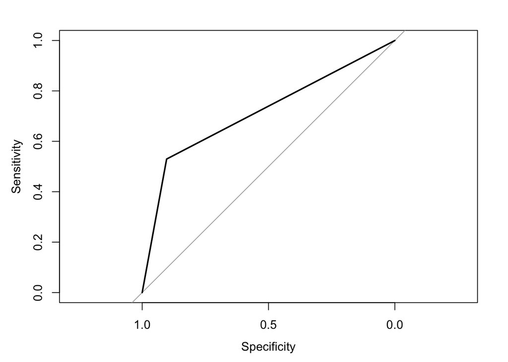

```r
# ROC & AUC
logit_train_roc <- roc(telcustomer_train_tbl$Churn_num, telcustomer_train_tbl$P_RESP)
logit_train_roc_plot <- plot(logit_train_roc)
```

```r
logit_train_auc <- pROC::auc(logit_train_roc)
logit_train_auc
```

```
## Area under the curve: 0.7164
```

```r
ci.auc(logit_train_auc)
```

```
## 95% CI: 0.7029-0.73 (DeLong)
```

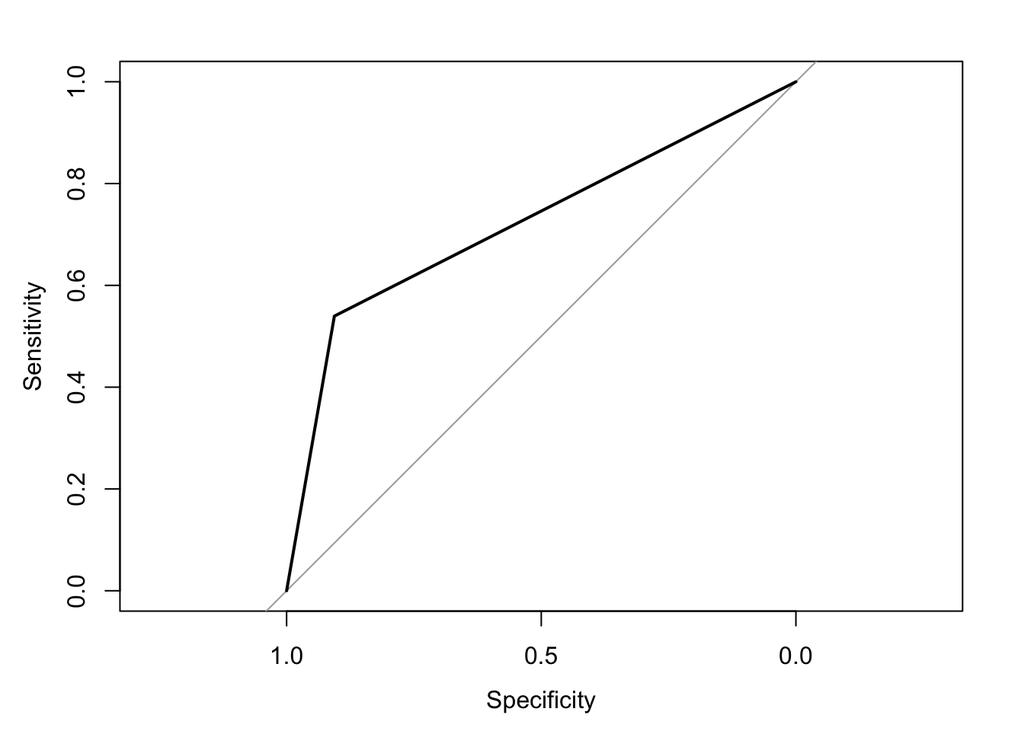

```r
# predict test
telcustomer_test_tbl <- telcustomer_test_tbl %>%
  mutate(P_TEST = predict(telcustomer_train_logit, newdata = telcustomer_test_tbl, type = "response"),
         P_RESP = ifelse(P_TEST >= 0.5, 1, 0))

# confusion matrix
logit_conf_mat <- table(telcustomer_test_tbl$Churn_num, telcustomer_test_tbl$P_RESP)

# ROC & AUC
logit_test_roc <- roc(telcustomer_test_tbl$Churn_num, telcustomer_test_tbl$P_RESP)
logit_test_roc_plot <- plot(logit_test_roc)
```

```r
logit_test_auc <- pROC::auc(logit_test_roc)
logit_test_auc
```

```
## Area under the curve: 0.7229
```

```r
ci.auc(logit_test_auc)
```

```
## 95% CI: 0.6969-0.7488 (DeLong)
```

##### Decision Tree

```r
# Decision Tree
telcustomer_train_dtree <- tree(Churn ~ gender+SeniorCitizen+Partner+Dependents+tenure+PhoneService+…, data=telcustomer_train_tbl)
summary(telcustomer_train_dtree)
```

```
##
## Classification tree:
## tree(formula = Churn ~ gender + SeniorCitizen + Partner + Dependents +
##     tenure + PhoneService + MultipleLines + InternetService +
##     OnlineSecurity + OnlineBackup + DeviceProtection + TechSupport +
##     StreamingTV + StreamingMovies + Contract + PaperlessBilling +
##     PaymentMethod + MonthlyCharges + TotalCharges, data = telcustomer_train_tbl)
## Variables actually used in tree construction:
## [1] "Contract"        "MonthlyCharges"  "InternetService" "tenure"
## Number of terminal nodes:  6
## Residual mean deviance:  0.8759 = 4922 / 5620
## Misclassification error rate: 0.2069 = 1164 / 5626
```

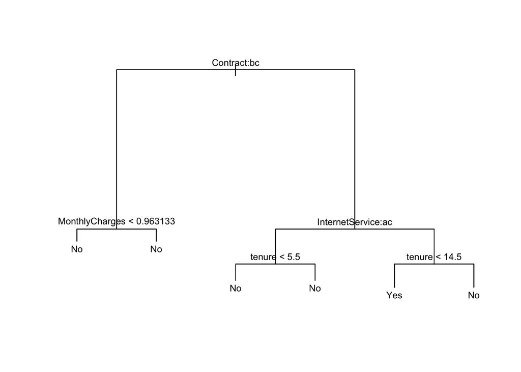

```r
# plot
plot(telcustomer_train_dtree)
text(telcustomer_train_dtree,cex=0.75)
```

```r
# tree prune
telcustomer_train_dtree_pruned <- prune.tree(telcustomer_train_dtree, best = 5)
summary(telcustomer_train_dtree_pruned)
```

```
##
## Classification tree:
## snip.tree(tree = telcustomer_train_dtree, nodes = 2L)
## Variables actually used in tree construction:
## [1] "Contract"        "InternetService" "tenure"
## Number of terminal nodes:  5
## Residual mean deviance:  0.8891 = 4998 / 5621
## Misclassification error rate: 0.2069 = 1164 / 5626
```

```r
# test
telcustomer_test_dtree_pruned <- prune.tree(telcustomer_train_dtree, best = 5, newdata = telcustomer_test_tbl)
telcustomer_test_dtree_pruned
```

```
## node), split, n, deviance, yval, (yprob)
##       * denotes terminal node
##
##  1) root 5626 6453.0 No ( 0.73960 0.26040 )
##    2) Contract: One year,Two year 2542 1269.0 No ( 0.93155 0.06845 ) *
##    3) Contract: Month-to-month 3084 4193.0 No ( 0.58139 0.41861 )
##      6) InternetService: DSL,No 1400 1651.0 No ( 0.72357 0.27643 )
##       12) tenure < 5.5 591  803.3 No ( 0.58206 0.41794 ) *
##       13) tenure > 5.5 809  745.4 No ( 0.82695 0.17305 ) *
##      7) InternetService: Fiber optic 1684 2325.0 Yes ( 0.46318 0.53682 )
##       14) tenure < 14.5 777  957.4 Yes ( 0.30631 0.69369 ) *
##       15) tenure > 14.5 907 1223.0 No ( 0.59757 0.40243 ) *
```

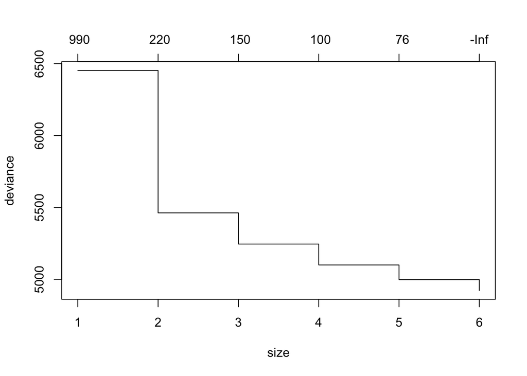

```r
telcustomer_test_dtree_seq = prune.tree(telcustomer_train_dtree)
plot(telcustomer_test_dtree_seq)
```

```r
# also vectorize the error rates for prunings
telcustomer_test_dtree_seq$dev
```

```
## [1] 4922.278 4997.779 5099.804 5245.139 5462.277 6452.718
```

```r
# find the size of the optimal trees with respect to MSE:
telcustomer_test_dtree_optimal <- which(telcustomer_test_dtree_seq$dev == min(telcustomer_test_dtree_seq$dev))
best_num_of_leaves <- min(telcustomer_test_dtree_seq$size[telcustomer_test_dtree_optimal])
best_num_of_leaves
```

```
## [1] 6
```

```r
# final tree
telcustomer_train_dtree_final <- prune.tree(telcustomer_train_dtree, best = best_num_of_leaves)
summary(telcustomer_train_dtree_final)
```

```
##
## Classification tree:
## tree(formula = Churn ~ gender + SeniorCitizen + Partner + Dependents +
##     tenure + PhoneService + MultipleLines + InternetService +
##     OnlineSecurity + OnlineBackup + DeviceProtection + TechSupport +
##     StreamingTV + StreamingMovies + Contract + PaperlessBilling +
##     PaymentMethod + MonthlyCharges + TotalCharges, data = telcustomer_train_tbl)
## Variables actually used in tree construction:
## [1] "Contract"        "MonthlyCharges"  "InternetService" "tenure"
## Number of terminal nodes:  6
## Residual mean deviance:  0.8759 = 4922 / 5620
## Misclassification error rate: 0.2069 = 1164 / 5626
```

```r
# test on new prune tree
telcustomer_test_dtree_pruned_7 <- prune.tree(telcustomer_train_dtree, best = best_num_of_leaves, newdata = telcustomer_test_tbl)
summary(telcustomer_test_dtree_pruned_7)
```

```
##
## Classification tree:
## tree(formula = Churn ~ gender + SeniorCitizen + Partner + Dependents +
##     tenure + PhoneService + MultipleLines + InternetService +
##     OnlineSecurity + OnlineBackup + DeviceProtection + TechSupport +
##     StreamingTV + StreamingMovies + Contract + PaperlessBilling +
##     PaymentMethod + MonthlyCharges + TotalCharges, data = telcustomer_train_tbl)
## Variables actually used in tree construction:
## [1] "Contract"        "MonthlyCharges"  "InternetService" "tenure"
## Number of terminal nodes:  6
## Residual mean deviance:  0.8759 = 4922 / 5620
## Misclassification error rate: 0.2069 = 1164 / 5626
```

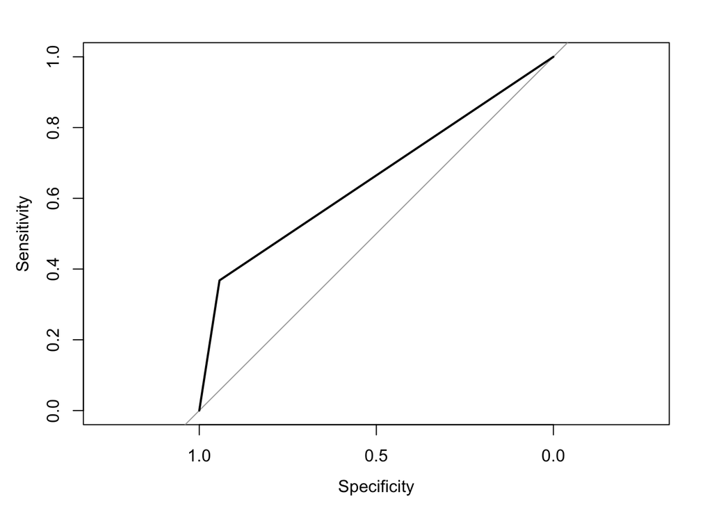

```r
# prediction on training data
dtree_train_pred <- predict(telcustomer_test_dtree_pruned_7, telcustomer_train_tbl, probability = TRUE)
dtree_train_prob <- data.frame(dtree_train_pred)
dtree_train_prob$Result <- ifelse(dtree_train_prob$No > dtree_train_prob$Yes, 0, 1)

# evaluate AUC & ROC
dtree_train_roc <- roc(telcustomer_train_tbl$Churn_num, dtree_train_prob$Result)
dtree_train_roc_plot <- plot(dtree_train_roc)
```

```r
dtree_train_auc <- pROC::auc(dtree_train_roc)
dtree_train_auc
```

```
## Area under the curve: 0.6554
```

```r
ci.auc(dtree_train_auc)
```

```
## 95% CI: 0.6425-0.6682 (DeLong)
```

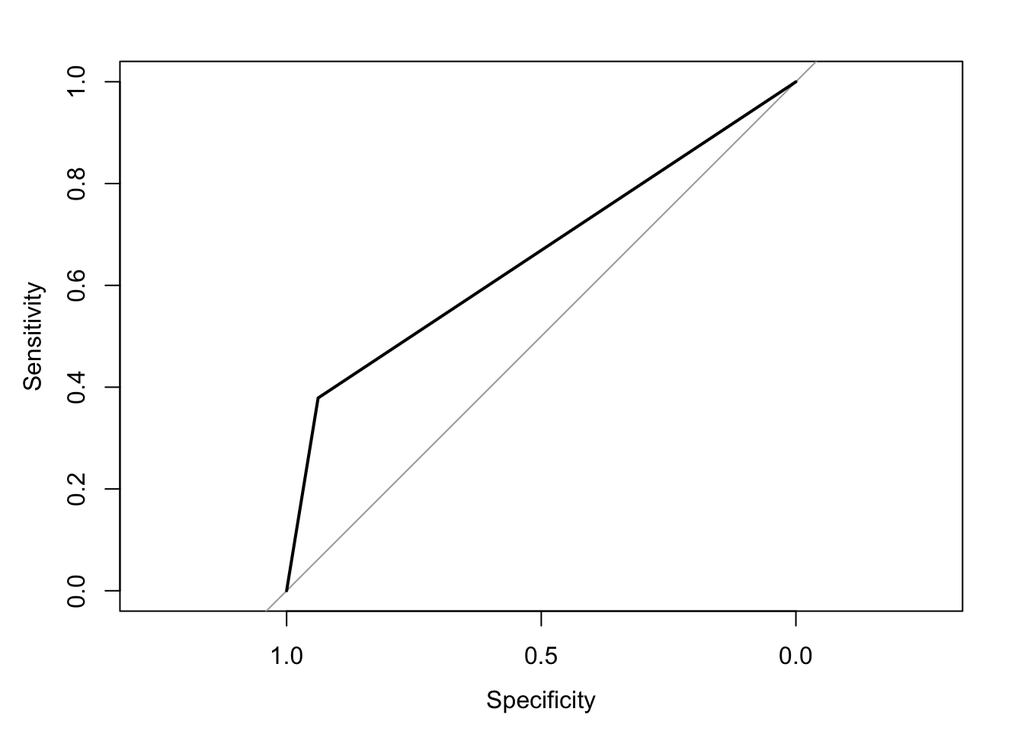

```r
# prediction on testing data
dtree_test_pred <- predict(telcustomer_test_dtree_pruned_7, telcustomer_test_tbl, probability = TRUE)
dtree_test_prob <- data.frame(dtree_test_pred)
dtree_test_prob$Result <- ifelse(dtree_test_prob$No > dtree_test_prob$Yes, 0, 1)

# confusion matrix
dtree_conf_mat <- table(telcustomer_test_tbl$Churn_num, dtree_test_prob$Result)

# evaluate AUC & ROC
dtree_test_roc <- roc(telcustomer_test_tbl$Churn_num, dtree_test_prob$Result)
dtree_test_roc_plot <- plot(dtree_test_roc)
```

```r
dtree_test_auc <- pROC::auc(dtree_test_roc)
dtree_test_auc
```

```
## Area under the curve: 0.6584
```

```r
ci.auc(dtree_test_auc)
```

```
## 95% CI: 0.6336-0.6832 (DeLong)
```

##### Support Vector Machine

```r
# SVM
telcustomer_train_svm <- svm(Churn ~ gender+SeniorCitizen+Partner+Dependents+tenure+PhoneService+…, probability = TRUE, data = telcustomer_train_tbl)

# summary
telcustomer_train_svm
```

```
##
## Call:
## svm(formula = Churn ~ gender + SeniorCitizen + Partner + Dependents +
##     tenure + PhoneService + MultipleLines + InternetService +
##     OnlineSecurity + OnlineBackup + DeviceProtection + TechSupport +
##     StreamingTV + StreamingMovies + Contract + PaperlessBilling +
##     PaymentMethod + MonthlyCharges + TotalCharges, data = telcustomer_train_tbl,
##     probability = TRUE)
##
##
## Parameters:
##    SVM-Type:  C-classification
##  SVM-Kernel:  radial
##        cost:  1
##       gamma:  0.03225806
##
## Number of Support Vectors:  2577
```

```r
summary(telcustomer_train_svm)
```

```
##
## Call:
## svm(formula = Churn ~ gender + SeniorCitizen + Partner + Dependents +
##     tenure + PhoneService + MultipleLines + InternetService +
##     OnlineSecurity + OnlineBackup + DeviceProtection + TechSupport +
##     StreamingTV + StreamingMovies + Contract + PaperlessBilling +
##     PaymentMethod + MonthlyCharges + TotalCharges, data = telcustomer_train_tbl,
##     probability = TRUE)
##
##
## Parameters:
##    SVM-Type:  C-classification
##  SVM-Kernel:  radial
##        cost:  1
##       gamma:  0.03225806
##
## Number of Support Vectors:  2577
##
##  ( 1322 1255 )
##
##
## Number of Classes:  2
##
## Levels:
##  No Yes
```

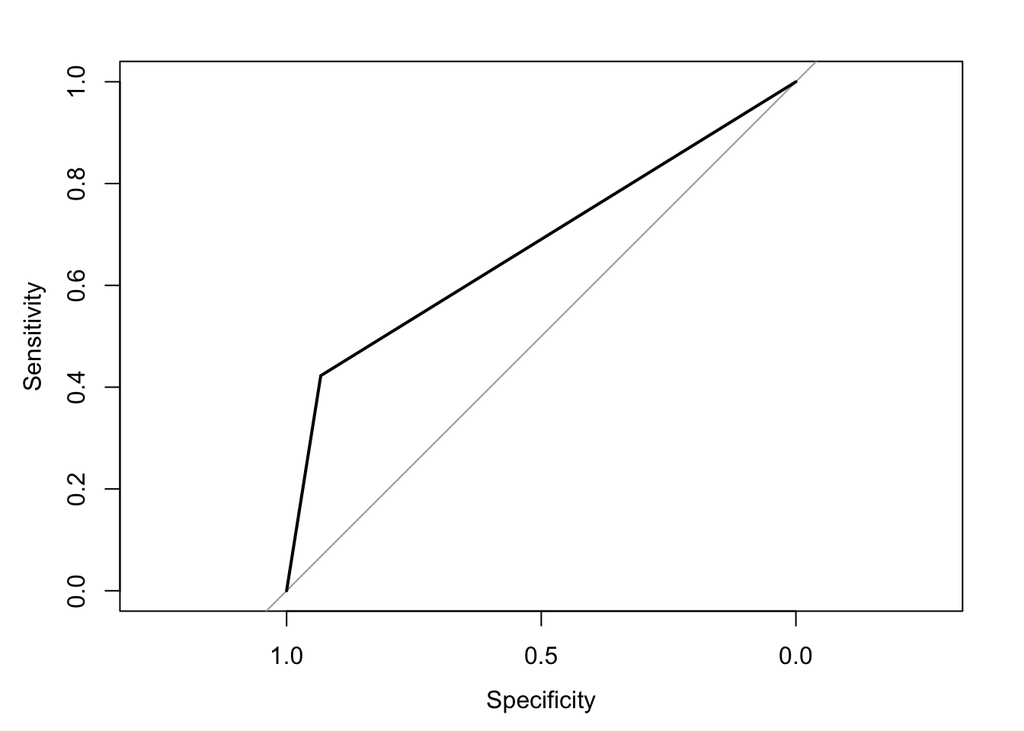

```r
svm_train_pred <- predict(telcustomer_train_svm, telcustomer_train_tbl, probability = TRUE)
svm_train_prob <- data.frame(attr(svm_train_pred, "probabilities"))
svm_train_prob$Result <- ifelse(svm_train_prob$No > svm_train_prob$Yes, 0, 1)

# evaluate AUC & ROC
svm_train_roc <- roc(telcustomer_train_tbl$Churn_num, svm_train_prob$Result)
svm_train_roc_plot <- plot(svm_train_roc)
```

```r
svm_train_auc <- pROC::auc(svm_train_roc)
svm_train_auc
```

```
## Area under the curve: 0.6777
```

```r
ci.auc(svm_train_auc)
```

```
## 95% CI: 0.6645-0.6909 (DeLong)
```

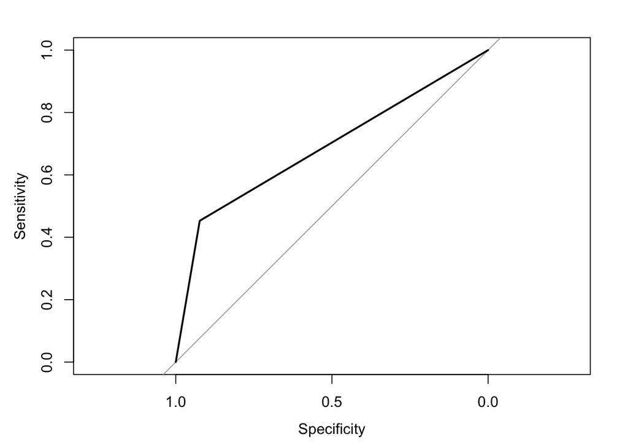

```r
# test predict
svm_test_pred <- predict(telcustomer_train_svm, telcustomer_test_tbl, probability = TRUE)
svm_test_prob <- data.frame(attr(svm_test_pred, "probabilities"))
svm_test_prob$Result <- ifelse(svm_test_prob$No > svm_test_prob$Yes, 0, 1)

# confusion matrix
svm_conf_mat <- table(telcustomer_test_tbl$Churn_num, svm_test_prob$Result)

# evaluate AUC & ROC
svm_test_roc <- roc(telcustomer_test_tbl$Churn_num, svm_test_prob$Result)
svm_test_roc_plot <- plot(svm_test_roc)
```

```r
svm_test_auc <- pROC::auc(svm_test_roc)
svm_test_auc
```

```
## Area under the curve: 0.6881
```

```r
ci.auc(svm_test_auc)
```

```
## 95% CI: 0.6624-0.7137 (DeLong)
```

##### Random Frost

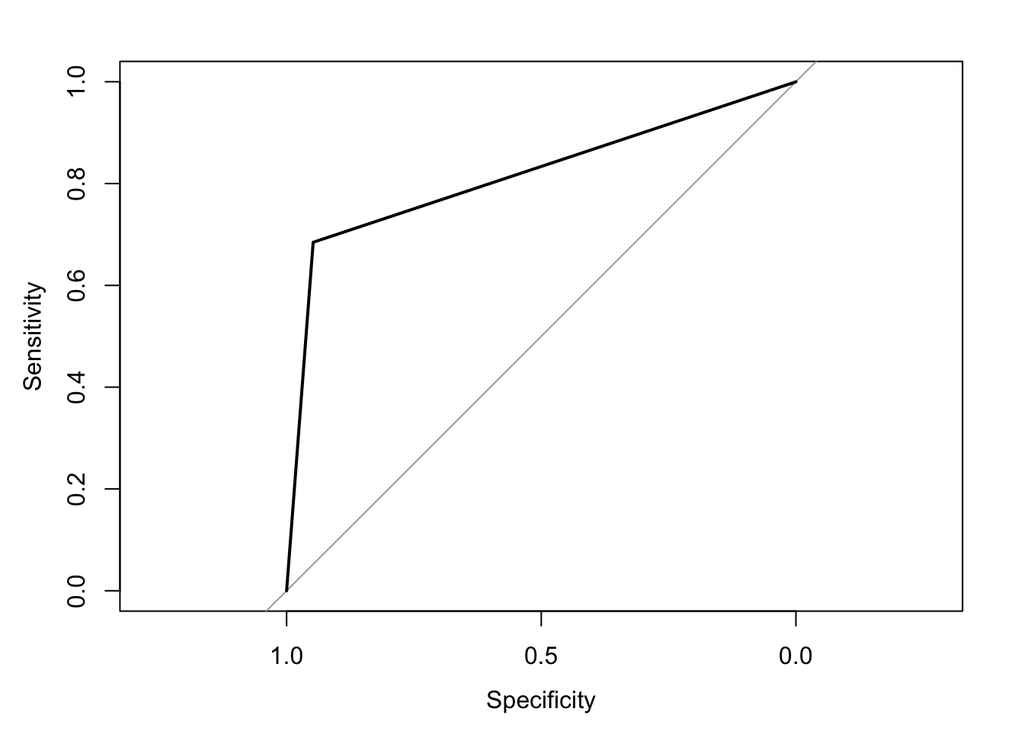

```r
# random forest in 10 features
set.seed(1234)
telcustomer_train_rf <- randomForest(formula = Churn ~ tenure+TotalCharges+Contract+MonthlyCharges+InternetService, data = telcustomer_train_tbl, importance = TRUE, ntree = 50)

# prediction on training data
rf_train_pred <- predict(telcustomer_train_rf, telcustomer_train_tbl, probability = TRUE)
rf_train_prob <- data.frame(rf_train_pred)
rf_train_prob$Result <- ifelse(rf_train_prob$rf_train_pred =="No", 0, 1)

# evaluate AUC & ROC
rf_train_roc <- roc(telcustomer_train_tbl$Churn_num, rf_train_prob$Result)
rf_train_roc_plot <- plot(rf_train_roc)
```

```r
rf_train_auc <- pROC::auc(rf_train_roc)
rf_train_auc
```

```
## Area under the curve: 0.8162
```

```r
ci.auc(rf_train_auc)
```

```
## 95% CI: 0.8039-0.8286 (DeLong)
```

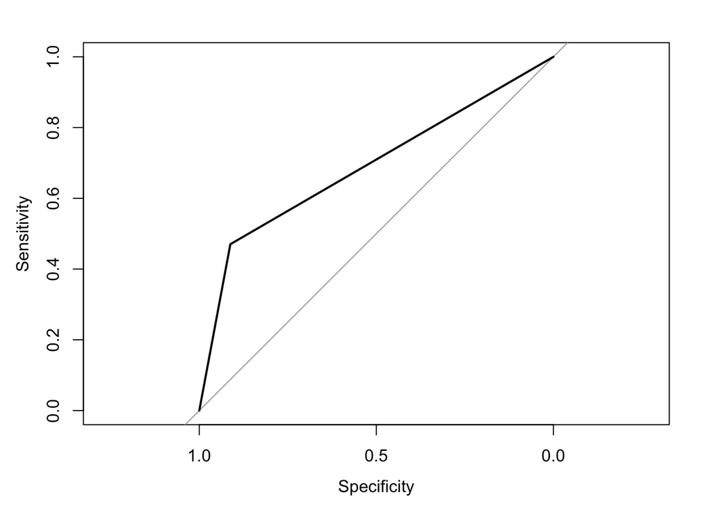

```r
# prediction on testing data
rf_test_pred <-predict(telcustomer_train_rf, telcustomer_test_tbl, probability = TRUE)
rf_test_prob <- data.frame(rf_test_pred)
rf_test_prob$Result <- ifelse(rf_test_prob$rf_test_pred =="No", 0, 1)

# confusion matrix
rf_conf_mat <- table(telcustomer_test_tbl$Churn_num, rf_test_prob$Result)

# evaluate AUC & ROC
rf_test_roc <- roc(telcustomer_test_tbl$Churn_num, rf_test_prob$Result)
rf_test_roc_plot <- plot(rf_test_roc)
```

```r
rf_test_auc <- pROC::auc(rf_test_roc)
rf_test_auc
```

```
## Area under the curve: 0.6912
```

```r
ci.auc(rf_test_auc)
```

```
## 95% CI: 0.6653-0.7171 (DeLong)
```

- Create an receiver operating characteristic curve for each model. What is the area under the receiver operating characteristic (AUC) for each of these models?
- The AUC of training dataset

```r
# train data AUC
logit_train_auc
```

```
## Area under the curve: 0.7164
```

```r
dtree_train_auc
```

```
## Area under the curve: 0.6554
```

```r
svm_train_auc
```

```
## Area under the curve: 0.6777
```

```r
rf_train_auc
```

```
## Area under the curve: 0.8162
```

- The AUC of testing dataset

```r
# test data AUC
logit_test_auc
```

```
## Area under the curve: 0.7229
```

```r
dtree_test_auc
```

```
## Area under the curve: 0.6584
```

```r
svm_test_auc
```

```
## Area under the curve: 0.6881
```

```r
rf_test_auc
```

```
## Area under the curve: 0.6912
```

- Which model performed best according to this metric?

From previous numbers, the AUC values of these four models present that the Logistic Regression model produce a best performance.

- How confident are you in your model? How do you quantify your confidence?

```r
#telcustomer_train_logit
#telcustomer_train_dtree
#telcustomer_train_svm
#telcustomer_train_rf

# train data MSE
log_train_mse <- mean((telcustomer_train_tbl$Churn_num - telcustomer_train_tbl$P_TEST)^2)
dtree_train_mse <- mean((telcustomer_train_tbl$Churn_num - dtree_train_prob$Result)^2)
svm_train_mse <- mean((telcustomer_train_tbl$Churn_num - svm_train_prob$Result)^2)
rf_train_mse <- mean((telcustomer_train_tbl$Churn_num - rf_train_prob$Result)^2)

# test data MSE
log_test_mse <- mean((telcustomer_train_tbl$Churn_num - telcustomer_test_tbl$P_TEST)^2)
dtree_test_mse <- mean((telcustomer_train_tbl$Churn_num - dtree_test_prob$Result)^2)
svm_test_mse <- mean((telcustomer_train_tbl$Churn_num - svm_test_prob$Result)^2)
rf_test_mse <- mean((telcustomer_train_tbl$Churn_num - rf_test_prob$Result)^2)
train_mse <- as.data.frame(cbind("train", log_train_mse,dtree_train_mse,svm_train_mse,rf_train_mse))
colnames(train_mse) <- c("type", "log_mse", "dtree_mse", "svm_mse", "rf_mse")
test_mse <- as.data.frame(cbind("test", log_test_mse,dtree_test_mse,svm_test_mse,rf_test_mse))
colnames(test_mse) <- c("type", "log_mse", "dtree_mse", "svm_mse", "rf_mse")

as.data.frame(rbind(train_mse,test_mse))
```

```
##    type           log_mse         dtree_mse           svm_mse
## 1 train 0.136233391887701 0.206896551724138 0.199964450764309
## 2  test 0.249592714123558 0.338784216139353  0.35335940277284
##              rf_mse
## 1 0.120689655172414
## 2  0.36402417348027
```

To consider which model performs better, we use MSE to evaluate the performance of models. The table above shows that although Logistic Regression is not the best model performing on training dataset, the performance on testing is best. And we also consider the values of AUC, which present us that Logistic Regression is performing best in test dataset among all these four models. Therefore, we think that, in this case, the Logistic Regression model is the best performing model in all these four models.

- Create a confusion matrix of true vs. predicted customer churn for your best model. How did you choose your threshold for classification? What is your accuracy, precision, sensitivity, specificity, F1 score, and negative predictive value for this model?

```r
# confusion matrix
logit_conf_mat
```

```
##
##       0   1
##   0 908  94
##   1 186 218
```

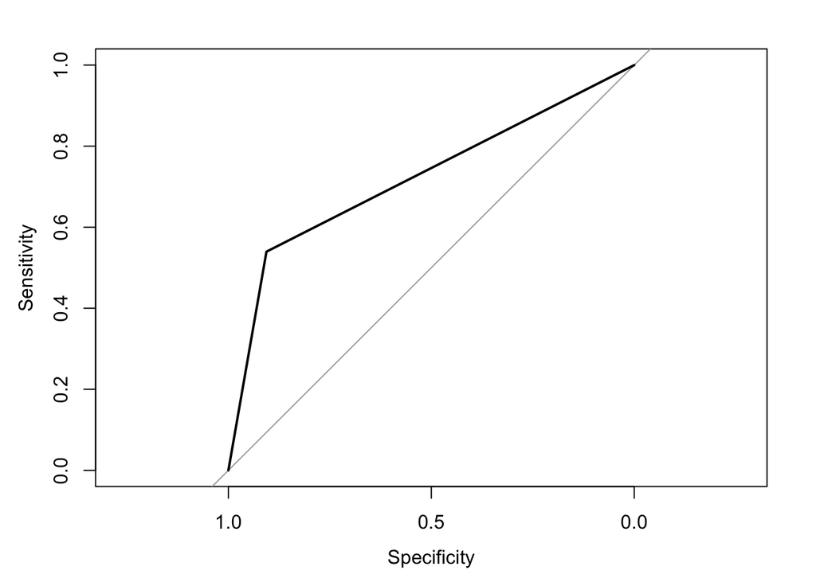

```r
# plot ROC graph
plot(logit_test_roc_plot)
```

```r
# find suitable threshold
table(telcustomer_test_tbl$Churn_num)
```

```
##
##    0    1
## 1002  404
```

```r
sum(telcustomer_test_tbl$Churn_num)/length(telcustomer_test_tbl$Churn_num)
```

```
## [1] 0.28734
```

```r
summary(telcustomer_test_tbl$P_TEST)
```

```
##     Min.  1st Qu.   Median     Mean  3rd Qu.     Max.
## 0.001332 0.061467 0.225942 0.277063 0.472599 0.799605
```

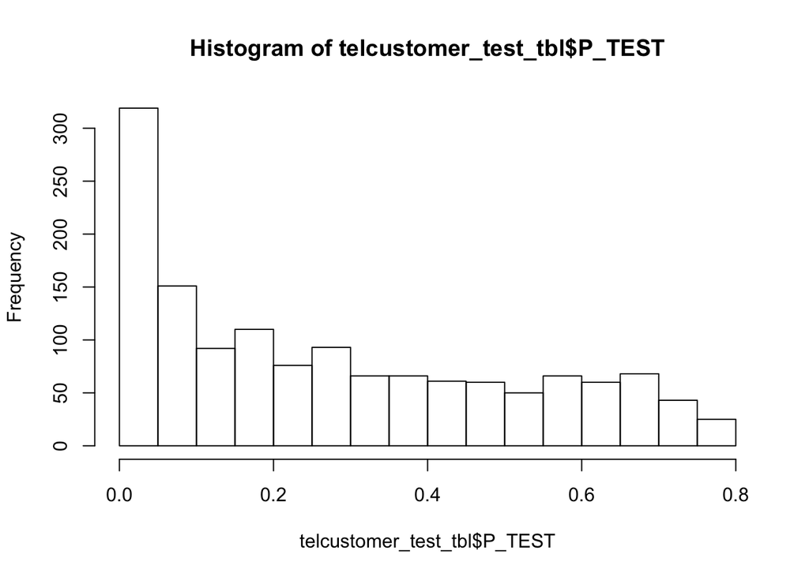

```r
hist(telcustomer_test_tbl$P_TEST)
```

```r
# AUC at different thresholds
telcustomer_test_logit_thresholds <- data.frame(ci.thresholds(logit_test_roc))
print(telcustomer_test_logit_thresholds)
```

```
##      specificity.2.5. specificity.50. specificity.97.5. sensitivity.2.5.
## -Inf        0.0000000       0.0000000         0.0000000         1.000000
## 0.5         0.8872255       0.9061876         0.9231537         0.490099
## Inf         1.0000000       1.0000000         1.0000000         0.000000
##      sensitivity.50. sensitivity.97.5.
## -Inf        1.000000         1.0000000
## 0.5         0.539604         0.5891089
## Inf         0.000000         0.0000000
```

In this case, we consider using Logistic Regression model as our best model. Therefore, the threshold for classification is 0.5 in this case.

And the measurements of the confusion matrix are presented in the following part.

```r
# Comparsion of these models
confusionMatrix(logit_conf_mat, mode = "everything", positive="1")
```

```
## Confusion Matrix and Statistics
##
##
##       0   1
##   0 908  94
##   1 186 218
##
##                Accuracy : 0.8009
##                  95% CI : (0.779, 0.8214)
##     No Information Rate : 0.7781
##     P-Value [Acc > NIR] : 0.02062
##
##                   Kappa : 0.4783
##  Mcnemar's Test P-Value : 5.379e-08
##
##             Sensitivity : 0.6987
##             Specificity : 0.8300
##          Pos Pred Value : 0.5396
##          Neg Pred Value : 0.9062
##               Precision : 0.5396
##                  Recall : 0.6987
##                      F1 : 0.6089
##              Prevalence : 0.2219
##          Detection Rate : 0.1550
##    Detection Prevalence : 0.2873
##       Balanced Accuracy : 0.7643
##
##        'Positive' Class : 1
##
```

- Evaluate your confusion matrix. Name one positive aspect of the results and one negative aspect of the results.

### Bonus question (10 pts - both parts need answered for credit):

- Create a lift table for your data. Display the table or a graph representing the table.

```r
# create a lift table
lift_tbl <- telcustomer_test_tbl[, c("P_TEST", "Churn_num")]
lift_tbl <- lift_tbl %>% arrange(desc(P_TEST))

# overall success probability in the evaluation dataset
baserate <- mean(telcustomer_test_tbl$Churn_num)
baserate
```

```
## [1] 0.28734
```

```r
# prepare fields for loop function
n_test <- length(telcustomer_test_tbl$Churn_num)
ax <- 1
ay_base <- baserate
ay_pred <- lift_tbl$Churn_num[1]

# create function to make new table variables
for (i in 2:n_test) {
  ax[i] = i
  ay_base[i] = baserate*i
  ay_pred[i] = ay_pred[i-1] + lift_tbl$Churn_num[i]
}

# create new dataframe for lift plot
df=cbind(lift_tbl,ay_pred,ay_base)
df[1:20,]
```

```
##       P_TEST Churn_num ay_pred   ay_base
## 1  0.7996055         1       1 0.2873400
## 2  0.7989565         1       2 0.5746799
## 3  0.7910038         0       2 0.8620199
## 4  0.7909550         1       3 1.1493599
## 5  0.7885037         1       4 1.4366999
## 6  0.7864479         1       5 1.7240398
## 7  0.7863624         1       6 2.0113798
## 8  0.7853052         1       7 2.2987198
## 9  0.7823842         1       8 2.5860597
## 10 0.7793747         0       8 2.8733997
## 11 0.7711720         1       9 3.1607397
## 12 0.7606030         1      10 3.4480797
## 13 0.7576371         1      11 3.7354196
## 14 0.7575801         0      11 4.0227596
## 15 0.7558653         1      12 4.3100996
## 16 0.7555735         1      13 4.5974395
## 17 0.7555463         1      14 4.8847795
## 18 0.7552146         1      15 5.1721195
## 19 0.7551354         1      16 5.4594595
## 20 0.7549718         1      17 5.7467994
```

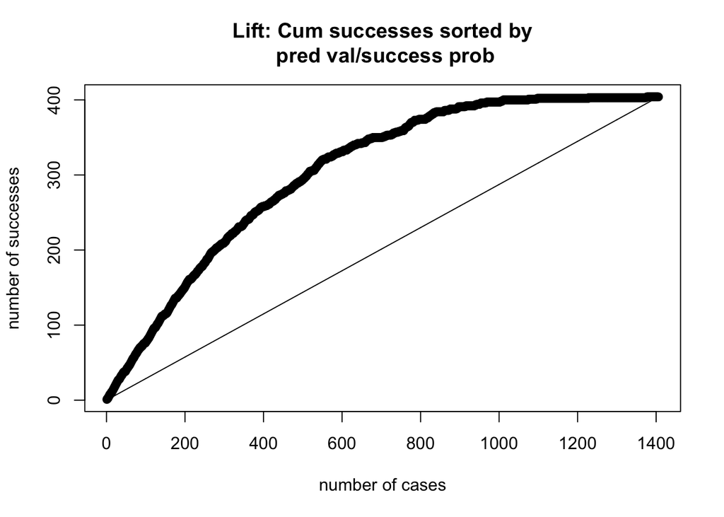

```r
plot(ax,ay_pred,xlab="number of cases",ylab="number of successes",
     main="Lift: Cum successes sorted by\n pred val/success prob")
points(ax,ay_base,type="l")
```

- Based on the totality of your analysis, how would you hypothetically suggest deploying this if you were working for this telco company?

Based on previous analysis, if the company is worry about a classification problem of Churn variable, we will suggest this telco company deploying a Logistic Regression model for predicting the variable. If the company require more detail explanations about how it decides, we will recommend deploying a Random Forest model for this task because of the precise boundary explanation produced by this model.